# OptimizationTP3

```python
import numpy as np
import pandas as pd
import matplotlib.pyplot as plt
from math import log2, sqrt
```

• Implement the functions phi(x,t,Q,p,A,b), grad(x,t,Q,p,A,b) and hess(x,t,Q,p,A,b) which return respectively the function value, gradient and hessian of φt(x) at point x.

```python
def phi(x,t,Q,p,A,b):
    self_concordant=-np.sum([log2(b[i]-np.dot(A[i][:],x)) for i in range(len(x))])
    return t*(0.5*np.dot(x,np.dot(Q,x))+np.dot(p,x))+self_concordant
```

```python
def grad(x,t,Q,p,A,b):
    self_concordant_gradient=[np.sum([A[i][k]/(b[i]-np.dot(A[i][:],x)) for i in range(len(x))]) for k in range(len(x))]
    return [t*(np.dot(Q[i][:],x)+p[i])+self_concordant_gradient[i] for i in range(len(x))]
```

```python
def hess(x,t,Q,p,A,b):
    self_concordant_hess=[[np.sum([(A[p][j]*A[p][i])/(b[p]-np.dot(A[p][:],x))**2 for p in range(len(x))]) for i in range(len(x))] for j in range(len(x))]
    return [[t*Q[i][j]+self_concordant_hess[i][j] for i in range(len(x))] for j in range(len(x))]
```

Please make sur that when calling those functions:  
- x,p and b are lists of elements (i.e x=[1,2,3] or np.array([1,2,3]))  
- Q and A are matrices (arrays) (i.e A=np.zeros((1,1)) or A=[[1]] when A is a scalar)).

• Implement the function [xnew,gap] = dampedNewtonStep(x,f,g,h), which compute the damped Newton step at point x.

```python
def dampedNewtonStep(x,f,g,h):
    gradient=g(x)
    hes=h(x)
    square_newton_decrement=np.dot(gradient,np.dot(np.linalg.inv(hes),gradient))
    x_new=list(x-(1/(1+sqrt(square_newton_decrement)))*np.dot(np.linalg.inv(hes),gradient))
    gap=square_newton_decrement/2
    return [x_new,gap]
```

• Implement the function [xstar,xhist] = dampedNewton(x0,f,g,h,tol) which min- imizes the function f starting at x0 using the damped Newton algorithm.

```python
def dampedNewton(x0,f,g,h,tol):
    xhist=[x0]
    [x_new,gap]=dampedNewtonStep(x0,f,g,h)
    xhist.append(x_new)
    while(gap>tol):
        [x_new,gap]=dampedNewtonStep(x_new,f,g,h)
        xhist.append(x_new)
    return [x_new,xhist]
```

• Implement a function [xstar,xhist] = newtonLS(x0,f,g,h,tol) which minimizes the function f starting at x0 using the Newton algorithm with backtracking line-search.

```python
def backtracking(x,f,g,direction,alpha,beta):
    t=1    # 0<alpha<0.5 and 0<beta<1
    f_x=f(x)
    gradient=g(x)
    while(f(np.array(x)+t*np.array(direction))>=f_x+alpha*t*np.dot(gradient,direction)):
        t=beta*t
    return t
```

```python
def newtonStep(x,f,g,h):
    gradient=g(x)
    hes=h(x)
    square_newton_decrement=np.dot(gradient,np.dot(np.linalg.inv(hes),gradient))
    step=list(-np.dot(np.linalg.inv(hes),gradient))
    gap=square_newton_decrement/2
    return [step,gap]
```

```python
def newtonLS(x0,f,g,h,tol):
    xhist=[x0]
    x=x0
    [step,gap]=newtonStep(x,f,g,h)
    xhist.append(x)
    while(gap>=tol):
        print(gap)
        t=backtracking(x,f,g,step,0.1,0.2)
        x=list(np.array(x)+t*np.array(step))
        [step,gap]=dampedNewtonStep(x,f,g,h)
        xhist.append(x)
    return [x,xhist]
```

```python
Q=[[10]]; p=[1]; A=[[2]]; b=[-1];t=0.001 # Declare some parameters t=0.001; # Set the barrier parameter
# Declare f as an anonymous function which takes one # input x, and returns phi(x,t,Q,p,A,b)
f = lambda x: phi(x,t,Q,p,A,b);
g = lambda x: grad(x,t,Q,p,A,b); # same
h = lambda x: hess(x,t,Q,p,A,b); # same
# Perform a Damped Newton Step at x=-1.
x0 =[-8];
print('For x0=[-8] the damped newton method returns:\n' ,dampedNewton(x0,f,g,h,0.01))
print('For x0=[-8] the newton method using backtracking line search returns:\n' ,newtonLS(x0,f,g,h,0.01))
x0 =[-2];
print('For x0=[-2] the damped newton method returns:\n' ,dampedNewton(x0,f,g,h,0.01))
print('For x0=[-2] the newton method using backtracking line search returns:\n' ,newtonLS(x0,f,g,h,0.01))
```

```
For x0=[-8] the damped newton method returns:
 [[-10.180161128926617], [[-8], [-9.4751131221719458], [-10.180161128926617]]]
For x0=[-8] the newton method using backtracking line search returns:
 [[-9.9559999999999995], [[-8], [-8], [-9.9559999999999995]]]
For x0=[-2] the damped newton method returns:
 [[-10.26449943792071], [[-2], [-2.7268556228748091], [-3.767785291471514], [-5.1826922604304571], [-6.9142506123286118], [-8.6500000213849013], [-9.8521766500884169], [-10.26449943792071]]]
For x0=[-2] the newton method using backtracking line search returns:
 [[-10.068226413660899], [[-2], [-2], [-3.4251833740831295], [-8.1536687132469226], [-10.068226413660899]]]
```

• coding the generic functions [Q,p,A,b] = transform svm primal(tau,X,y) and [Q,p,A,b] = transform svm dual(tau,X,y), which writes the primal and the dual SVM problem as particular instances of the quadratic problem (QP).

```python
def transform_svm_primal(tau,X,y):
    n,d=np.shape(X)[0],np.shape(X)[1]
    Q=np.zeros((n+d,n+d))
    Q[:d,:d]=np.eye(d)
    p1,p2=list(np.zeros(d)),list((1/(tau*n))*np.ones(n))
    p=np.array(p1+p2)
    b1,b2=list(-np.ones(n)),list(np.zeros(n))
    b=np.array(b1+b2)
    A=np.zeros((2*n,n+d))
    for i in range(n):
        A[i,:d]=-y[i]*X[i]
        A[i,d:]=list(-np.eye(n)[i])
        A[n+i,:d]=0
        A[n+i,d:]=list(-np.eye(n)[i])
    return [Q,p,A,b]
```

```python
def transform_svm_dual(tau,X,y):
    n,d=np.shape(X)[0],np.shape(X)[1]
    Q=np.array([[y[i]*y[j]*np.dot(X[i],X[j].T) for i in range(n)] for j in range(n)])
    p=-np.ones(n)
    A=np.zeros((2*n,n))
    b1,b2=list((1/(tau*n))*np.ones(n)),list(np.zeros(n))
    b=np.array(b1+b2)
    for i in range(n):
        A[i,:]=list(np.eye(n)[i])
        A[n+i,:]=list(-np.eye(n)[i])
    return [Q,p,A,b]
```

See the handwriting for the justifications.

• coding a function [x sol,xhist] = barr method(Q,p,A,b,x 0,mu,tol) which implements the barrier method to solve QP given the inputs (Q, p, A, b) and the initial point x_0 (which should be strictly feasible).

```python
def barr_method(Q,p,A,b,x0,mu,tol):
    t=30
    f = lambda z: phi(z,t,Q,p,A,b)
    g = lambda z: grad(z,t,Q,p,A,b)
    h = lambda z: hess(z,t,Q,p,A,b)
    xhist=[x0]
    x_opt=dampedNewton(x0,f,g,h,tol)[0]
    xhist.append(x_opt)
    m=np.shape(A)[0]
    while(m>=t*tol):
        x_opt=dampedNewton(x_opt,f,g,h,tol)[0]
        xhist.append(x_opt)
        t=mu*t
    return[x_opt,xhist]
```

initializing with t=30 for fast convergence, we will use another small value as example but it takes much more time due to the expensive calculations

```python
names=['sepal_length','sepal_width','petal_length','petal_width','classes','offset']
df=pd.read_table('/Users/adilrhiulam/Downloads/iris.data.txt',sep=',',names=names)
offset=np.mean(df[['sepal_length','sepal_width','petal_length','petal_width']].values,axis=1)
df[['offset']]=offset
```

loading the data and adding the offset column

```python
data=df[(df.classes=='Iris-virginica') | (df.classes=='Iris-versicolor')]
X=data[['sepal_length','sepal_width','petal_length','petal_width','offset']].values
classes=data[['classes']].values
Y=[]
for i in range(len(classes)):
    if classes[i][0]=='Iris-versicolor':
        Y.append(1)
    else:
        Y.append(-1)
X_train=X[:int(80*len(X)/100)]
Y_train=Y[:int(80*len(X)/100)]
X_test=X[int(80*len(X)/100):]
Y_test=Y[int(80*len(X)/100):]
```

Train data represent 80% of data and test data 20%

```python
def accuracy(true_labels,predicted_labels):
    count=0
    for i in range(len(true_labels)):
        if true_labels[i]==predicted_labels[i]:
            count+=1
    return count/len(true_labels)
```

Accuracy function on predicted labels (for train or test data).

tau=80:

```python
[Q,p,A,b]=transform_svm_primal(80,X_train,Y_train)
```

```python
(n,d)=np.shape(X_train)
w=np.zeros(d)
w[0]=1
z=np.zeros(n)
for i in range(n):
    r=2-Y_train[i]*X_train[i][0]
    z[i]=np.max([0.5,r])
x0=np.array(list(w)+list(z))
```

Initializing with the strict feasible point. (see the handwritting answers for demo)

```python
[x_opt,xhist]=barr_method(Q,p,A,b,x0,20,0.1)
print('The optimal abscisse is for tau=80:',x_opt)
```

```
The optimal abscisse is for tau=80: [0.013041908427347391, 0.0067724632430134048, 0.0052771363341868891, 0.00040171413413219061, 0.0063733042643190525, 21.799693997824495, 21.804867358368078, 21.800071436404188, 21.817626606212297, 21.805488877588704, 11.546487653807036, 11.531551019934554, 11.57038…
```

```python
w_estimated=np.array(x_opt)[:d]
Y_est_test=[int(np.sign(np.dot(w_estimated,X_test[i]))) for i in range(len(X_test))]
Y_est_train=[int(np.sign(np.dot(w_estimated,X_train[i]))) for i in range(len(X_train))]
print('The accuracy on train_data predicted for tau=80 is:',accuracy(Y_train,Y_est_train))
print('The accuracy on test_data predicted for tau=80 is:',accuracy(Y_test,Y_est_test))
```

```
The accuracy on train_data predicted for tau=80 is: 0.625
The accuracy on test_data predicted for tau=80 is: 0.0
```

Poor classification for that choice of tau, all predicted labels are incorrect for test data.

tau=50:

```python
[Q,p,A,b]=transform_svm_primal(50,X_train,Y_train)
(n,d)=np.shape(X_train)
w=np.zeros(d)
w[0]=1
z=np.zeros(n)
for i in range(n):
    r=2-Y_train[i]*X_train[i][0]
    z[i]=np.max([0.5,r])
x0=np.array(list(w)+list(z))
```

```python
[x_opt,xhist]=barr_method(Q,p,A,b,x0,20,0.1)
```

```python
print('The optimal abscisse is for tau=50, mu=20, t0=30:',m)
```

```
The optimal abscisse is for tau=50, mu=20, t0=30: [0.020900755016298272, 0.010851152336996576, 0.008467126030203635, 0.0006502723876276507, 0.010217324383746347, 13.737019070090195, 13.745441277333883, 13.737631697940293, 13.766238506326763, 13.746452434156986, 7.454290347386235, 7.430348885148202, …
```

```python
w_estimated=np.array(x_opt)[:d]
Y_est_test=[int(np.sign(np.dot(w_estimated,X_test[i]))) for i in range(len(X_test))]
Y_est_train=[int(np.sign(np.dot(w_estimated,X_train[i]))) for i in range(len(X_train))]
print('The accuracy on train_data predicted for tau=50 is:',accuracy(Y_train,Y_est_train))
print('The accuracy on test_data predicted for tau=50 is:',accuracy(Y_test,Y_est_test))
```

```
The accuracy on train_data predicted for tau=50 is: 0.625
The accuracy on test_data predicted for tau=50 is: 0.0
```

Poor classification, we should decrease tau.

tau=5 with the use of the dual problem

```python
tau=5
[Q,p,A,b]=transform_svm_dual(tau,X_train,Y_train)
(n,d)=np.shape(X_train)
lamda_feasible=[1/(2*tau*n) for i in range(n)]
```

Strict feasible point for initialization for dual problem, see the handwriting for demo

```python
[x_opt,xhist]=barr_method(Q,p,A,b,lamda_feasible,20,0.1)
print('The optimal value for the dual problem is for tau=5:',x_opt)
```

```
The optimal value for the dual problem is for tau=5: [0.00063971717410782824, 0.00066033018118423373, 0.00065435871884055496, 0.00070104755561441515, 0.0006701192762461058, 0.00069339409265536456, 0.0006693544849131701, 0.00069556727967519155, 0.00065858639855438553, 0.00070146114701329857, 0.000707…
```

```python
w_estimated=np.sum([x_opt[i]*Y_train[i]*X_train[i] for i in range(len(x_opt))],axis=0)
Y_est_test=[int(np.sign(np.dot(w_estimated,X_test[i]))) for i in range(len(X_test))]
Y_est_train=[int(np.sign(np.dot(w_estimated,X_train[i]))) for i in range(len(X_train))]
print('The accuracy on train_data predicted for tau=5 is:',accuracy(Y_train,Y_est_train))
print('The accuracy on test_data predicted for tau=5 is:',accuracy(Y_test,Y_est_test))
```

```
The accuracy on train_data predicted for tau=5 is: 0.625
The accuracy on test_data predicted for tau=5 is: 0.0
```

Poor classification, all predicted classes are incorrect.

tau=0.1

```python
tau=0.1
[Q,p,A,b]=transform_svm_dual(tau,X_train,Y_train)
(n,d)=np.shape(X_train)
lamda_feasible=[1/(2*tau*n) for i in range(n)]
```

```python
[x_opt,xhist]=barr_method(Q,p,A,b,lamda_feasible,20,0.1)
print('The optimal value for the dual problem is for tau=0.1, t0=30 and mu=20:',x_opt)
```

```
The optimal value for the dual problem is for tau=0.1, t0=30 and mu=20: [0.11176763496951476, 0.12041935457605729, 0.1208687854834351, 0.12272650049077397, 0.12197138119192312, 0.12261219454177777, 0.12198698391893892, 0.1200717473529444, 0.11952718667731341, 0.12266857799398208, 0.12212486863108546…
```

```python
w_estimated=np.sum([x_opt[i]*Y_train[i]*X_train[i] for i in range(len(x_opt))],axis=0)
Y_est_test=[int(np.sign(np.dot(w_estimated,X_test[i]))) for i in range(len(X_test))]
Y_est_train=[int(np.sign(np.dot(w_estimated,X_train[i]))) for i in range(len(X_train))]
print('The accuracy on train_data predicted for tau=0.1 is:',accuracy(Y_train,Y_est_train))
print('The accuracy on test_data predicted for tau=0.1 is:',accuracy(Y_test,Y_est_test))
```

```
The accuracy on train_data predicted for tau=0.1 is: 0.975
The accuracy on test_data predicted for tau=0.1 is: 0.9
```

Good performance, then we deduce that tau should be choosen small for good accuracy.

```python
def barr_method_bis(Q,p,A,b,x0,mu,tol):
    t=1
    f = lambda z: phi(z,t,Q,p,A,b)
    g = lambda z: grad(z,t,Q,p,A,b)
    h = lambda z: hess(z,t,Q,p,A,b)
    xhist=[x0]
    x_opt=dampedNewton(x0,f,g,h,tol)[0]
    xhist.append(x_opt)
    m=np.shape(A)[0]
    while(m>=t*tol):
        x_opt=dampedNewton(x_opt,f,g,h,tol)[0]
        xhist.append(x_opt)
        t=mu*t
    return [x_opt,xhist]
```

Using t=1 instead of 30 in this function

```python
tau=0.1
[Q,p,A,b]=transform_svm_dual(tau,X_train,Y_train)
(n,d)=np.shape(X_train)
lamda_feasible=[1/(2*tau*n) for i in range(n)]
```

```python
[x_opt,xhist]=barr_method_bis(Q,p,A,b,lamda_feasible,15,0.01)
print('The optimal value for the dual problem is for tau=0.1, t0=1 and mu=14:',x_opt)
```

```
The optimal value for the dual problem is for tau=0.1, t0=1 and mu=14: [0.12267070677020703, 0.12419875051778635, 0.12427022980985092, 0.12459753336850518, 0.1244648257821923, 0.12457796294084364, 0.12447224841812642, 0.12413036678312782, 0.12402760527931571, 0.12459026431178616, 0.12448869230442362…
```

```python
w_estimated=np.sum([x_opt[i]*Y_train[i]*X_train[i] for i in range(len(x_opt))],axis=0)
Y_est_test=[int(np.sign(np.dot(w_estimated,X_test[i]))) for i in range(len(X_test))]
Y_est_train=[int(np.sign(np.dot(w_estimated,X_train[i]))) for i in range(len(X_train))]
print('The accuracy on train_data predicted for tau=0.1 is:',accuracy(Y_train,Y_est_train))
print('The accuracy on test_data predicted for tau=0.1 is:',accuracy(Y_test,Y_est_test))
```

```
The accuracy on train_data predicted for tau=0.1 is: 0.9625
The accuracy on test_data predicted for tau=0.1 is: 0.9
```

Very good performance

4. Plot the duality gap versus iterations (using the damped Newton Method) for the primal and dual problem in semilog-scale for different values of the barrier method parameter μ = 2, 15, 50, 100 and comment the results.

```python
def duality_gap(Q,p,A,b,x0,mu,tol):
    duality_gap=[]
    t=1
    f = lambda z: phi(z,t,Q,p,A,b)
    g = lambda z: grad(z,t,Q,p,A,b)
    h = lambda z: hess(z,t,Q,p,A,b)
    xhist=[x0]
    x_opt=dampedNewton(x0,f,g,h,tol)[0]
    xhist.append(x_opt)
    m=np.shape(A)[0]
    duality_gap.append(m/t)
    itera=0
    while(m>=t*tol):
        x_opt=dampedNewton(x_opt,f,g,h,tol)[0]
        xhist.append(x_opt)
        t=mu*t
        duality_gap.append(m/t)
        itera+=1
    return [itera,duality_gap]
```

The duality_gap function returns the number of inner iterations until the while criteria is attained and all the duality gap values over those iterations in a list.

```python
tau=0.1
[Q,p,A,b]=transform_svm_dual(tau,X_train,Y_train)
(n,d)=np.shape(X_train)
lambda_feasible=[1/(2*tau*n) for i in range(n)]
```

```python
dual_gap_dual_1=duality_gap(Q,p,A,b,lambda_feasible,2,0.01)
print('The evolution of the duality gap for the dual problem and mu=2 is :\n',dual_gap_dual_1[1])
```

```
The evolution of the duality gap for the dual problem and mu=2 is :
 [160.0, 80.0, 40.0, 20.0, 10.0, 5.0, 2.5, 1.25, 0.625, 0.3125, 0.15625, 0.078125, 0.0390625, 0.01953125, 0.009765625]
```

```python
dual_gap_dual_2=duality_gap(Q,p,A,b,lambda_feasible,15,0.01)
print('The evolution of the duality gap for the dual problem and mu=15 is :\n',dual_gap_dual_2[1])
```

```
The evolution of the duality gap for the dual problem and mu=15 is :
 [160.0, 10.666666666666666, 0.7111111111111111, 0.047407407407407405, 0.0031604938271604936]
```

```python
dual_gap_dual_3=duality_gap(Q,p,A,b,lambda_feasible,50,0.01)
print('The evolution of the duality gap for the dual problem and mu=50 is :\n',dual_gap_dual_3[1])
```

```
The evolution of the duality gap for the dual problem and mu=50 is :
 [160.0, 3.2, 0.064, 0.00128]
```

```python
dual_gap_dual_4=duality_gap(Q,p,A,b,lambda_feasible,100,0.01)
print('The evolution of the duality gap for the dual problem and mu=100 is :\n',dual_gap_dual_4[1])
```

```
The evolution of the duality gap for the dual problem and mu=100 is :
 [160.0, 1.6, 0.016, 0.00016]
```

```python
[Q,p,A,b]=transform_svm_primal(0.1,X_train,Y_train)
(n,d)=np.shape(X_train)
w=np.zeros(d)
w[0]=1
z=np.zeros(n)
for i in range(n):
    r=2-Y_train[i]*X_train[i][0]
    z[i]=np.max([0.5,r])
x0=np.array(list(w)+list(z))
```

```python
dual_gap_prim_1=duality_gap(Q,p,A,b,x0,2,0.01)
print('The evolution of the duality gap for the primal problem and mu=2 is :\n',dual_gap_prim_1[1])
```

```
The evolution of the duality gap for the primal problem and mu=2 is :
 [160.0, 80.0, 40.0, 20.0, 10.0, 5.0, 2.5, 1.25, 0.625, 0.3125, 0.15625, 0.078125, 0.0390625, 0.01953125, 0.009765625]
```

```python
dual_gap_prim_2=duality_gap(Q,p,A,b,x0,15,0.01)
print('The evolution of the duality gap for the primal problem and mu=15 is :\n',dual_gap_prim_2[1])
```

```
The evolution of the duality gap for the primal problem and mu=15 is :
 [160.0, 10.666666666666666, 0.7111111111111111, 0.047407407407407405, 0.0031604938271604936]
```

```python
dual_gap_prim_3=duality_gap(Q,p,A,b,x0,50,0.01)
print('The evolution of the duality gap for the primal problem and mu=50 is :\n',dual_gap_prim_3[1])
```

```
The evolution of the duality gap for the primal problem and mu=50 is :
 [160.0, 3.2, 0.064, 0.00128]
```

```python
dual_gap_prim_4=duality_gap(Q,p,A,b,x0,100,0.01)
print('The evolution of the duality gap for the primal problem and mu=100 is :\n',dual_gap_prim_4[1])
```

```
The evolution of the duality gap for the primal problem and mu=100 is :
 [160.0, 1.6, 0.016, 0.00016]
```

```python
dual_gap_prim_1==dual_gap_dual_1
```

```
True
```

```python
dual_gap_prim_2==dual_gap_dual_2
```

```
True
```

```python
dual_gap_prim_3==dual_gap_dual_3
```

```
True
```

```python
dual_gap_prim_4==dual_gap_dual_4
```

```
True
```

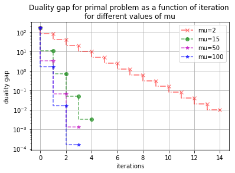

```python
plt.step([x for x in range(dual_gap_prim_1[0]+1)],dual_gap_prim_1[1],c='r',linestyle='-.',marker='x',alpha=0.6,label="mu=2")
plt.step([x for x in range(dual_gap_prim_2[0]+1)],dual_gap_prim_2[1],c='g',linestyle='dashed',marker='o',alpha=0.6,label="mu=15")
plt.step([x for x in range(dual_gap_prim_3[0]+1)],dual_gap_prim_3[1],c='m',linestyle='dashed',marker='*',alpha=0.6,label="mu=50")
plt.step([x for x in range(dual_gap_prim_4[0]+1)],dual_gap_prim_4[1],c='b',linestyle='dashed',marker='*',alpha=0.6,label="mu=100")
plt.xlabel('iterations')
plt.ylabel('duality gap')
plt.legend()
plt.title('Duality gap for primal problem as a function of iteration \nfor different values of mu')
plt.yscale('log')
plt.grid()
plt.show()
```

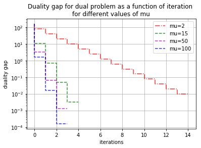

```python
plt.step([x for x in range(dual_gap_dual_1[0]+1)],dual_gap_dual_1[1],c='r',linestyle='-.',alpha=0.8,label="mu=2")
plt.step([x for x in range(dual_gap_dual_2[0]+1)],dual_gap_dual_2[1],c='g',linestyle='dashed',alpha=0.8,label="mu=15")
plt.step([x for x in range(dual_gap_dual_3[0]+1)],dual_gap_dual_3[1],c='m',linestyle='dashed',alpha=0.8,label="mu=50")
plt.step([x for x in range(dual_gap_dual_4[0]+1)],dual_gap_dual_4[1],c='b',linestyle='dashed',alpha=0.8,label="mu=100")
plt.xlabel('iterations')
plt.ylabel('duality gap')
plt.legend()
plt.title('Duality gap for dual problem as a function of iteration \nfor different values of mu')
plt.yscale('log')
plt.grid()
plt.show()
```

The figure below show the evolution of the duality gap evolution with the number of inner iterations of the barrier method using as parameters: t0=1, tol=0.01 and tau=0.1 and diffrent values of mu. We can notice that the primal and dual problems give the same duality gap evolution, For mu=2 the condition of optimality approximation to respect is attained at the 14-th iteration while for mu=15 it's for 4-th iteration and 3-th iteration for mu=50 and mu=100, The width of each horizental step is the number of damped Newton steps calculated for that outer iteration. The height of each vertical step is equal to a multiple of mu because the duality gap is reduced by the factor mu at the end of each outer iteration.

The figure illustrates also the trade-off of the value mu, when mu is small the steps are short because the duality gap is reduced only by a factor of 2 per outer iteration. In contrast, mu=100 the steps are large since the duality gap is reduced only by a factor of 100 per outer iteration.

Compare the performance with the line-search strategy. Hint: Use the fact that any primal solution is an upper bound for the dual problem and vice-versa.

```python
def duality_gap_line_search(Q,p,A,b,x0,mu,tol):
    duality_gap=[]
    t=1
    f = lambda z: phi(z,t,Q,p,A,b)
    g = lambda z: grad(z,t,Q,p,A,b)
    h = lambda z: hess(z,t,Q,p,A,b)
    xhist=[x0]
    x_opt=newtonLS(x0,f,g,h,tol)[0]
    xhist.append(x_opt)
    m=np.shape(A)[0]
    duality_gap.append(m/t)
    itera=0
    while(m>=t*tol):
        x_opt=newtonLS(x_opt,f,g,h,tol)[0]
        xhist.append(x_opt)
        t=mu*t
        duality_gap.append(m/t)
        itera+=1
    return [itera,duality_gap]
```

Calculating the duality gap evolution with iteration using the line_search method (back-tracking).

```python
tau=0.1
[Q,p,A,b]=transform_svm_dual(tau,X_train,Y_train)
(n,d)=np.shape(X_train)
lambda_feasible=[1/(2*tau*n) for i in range(n)]
```

```python
dual_gap_prim_line_search=duality_gap_line_search(Q,p,A,b,lambda_feasible,2,0.1)
```

The newton step method takes much more time than the damped one, this depends on the choice of the feasible point that we initiliazed because the newton decrements is large and then the newton method could not converge